# GSEA MYC

## Prostatectomy Epithelial Clusters GSEA

For the analysis, I adapted this workflow to our dataset: https://crazyhottommy.github.io/scRNA-seq-workshop-Fall-2019/scRNAseq_workshop_3.html

```r
# Libraries
library(Seurat)
```

```r
library(ggplot2)
library(RColorBrewer)
library(dplyr)
library(tidyverse)
library(DataCombine)
library(msigdbr)
library(presto)
library(fgsea)
library(SeuratWrappers)
library(UCell)
# set working directory
wrkdir <- "C:/Users/mgraha21/OneDrive - Johns Hopkins/Mindy JHMI Onedrive/MYC prostate scRNAseq/Manuscript Version of Analysis/Github uploads" #update specific to user
setwd(wrkdir)
```

load dataframes

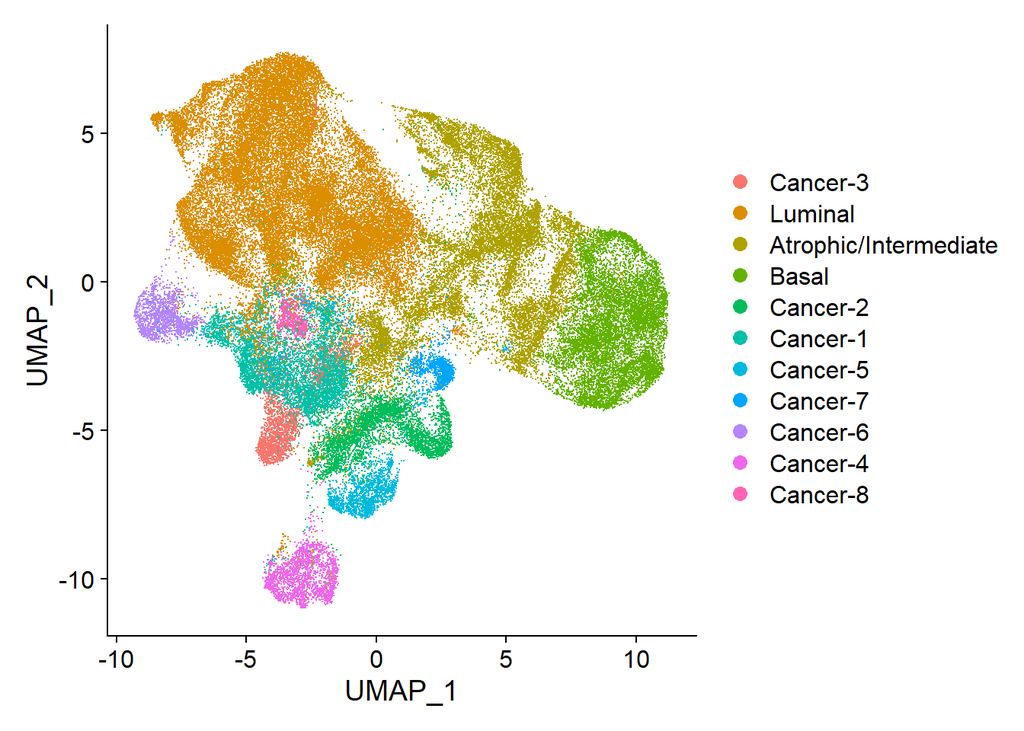

```r
# load seurat object
seurat_epi <- readRDS(file = "seurat_epi.rds")

Idents(seurat_epi) <- "epithelial_clusters"
DimPlot(seurat_epi)
```

# Make gene lists from MSigDB

```r
# select hallmark geneset
hallmark_gene_sets <- msigdbr(species = "human", category = "H")

# select MYC Dang targets up from C2 collection
C2_CGP_gene_sets <- msigdbr(species = "human", category = "C2", subcategory = "CGP")
Dang_gene_sets <- C2_CGP_gene_sets %>% filter(gs_name %in% c("DANG_MYC_TARGETS_UP"))

# combined datsets
GSEA_gs <- rbind(Dang_gene_sets, hallmark_gene_sets)
fgsea_sets<- GSEA_gs %>% split(x = .$gene_symbol, f = .$gs_name)
```

# GSESA Cancer vs Luminal by cluster

Cancer1 vs Luminal: Differential expression analysis for ranked list and GSEA for Hallmark Presto performs a fast Wilcoxon rank sum test and auROC analysis.

```r
Cancer1_genes <- wilcoxauc(X = seurat_epi, group_by = 'epithelial_clusters', seurat_assay = 'SCT', assay = 'data', groups_use = c("Cancer-1", "Luminal"))
head(Cancer1_genes)
```

```
##      feature    group     avgExpr         logFC statistic       auc
## 1 AL627309.1 Cancer-1 0.000000000 -0.0001333317  96988460 0.4999038
## 2 AL669831.5 Cancer-1 0.031640142 -0.0102718330  95710546 0.4933171
## 3     FAM87B Cancer-1 0.000000000  0.0000000000  97007120 0.5000000
## 4  LINC00115 Cancer-1 0.020189296  0.0039349563  97564854 0.5028747
## 5     FAM41C Cancer-1 0.002451646 -0.0013483081  96818422 0.4990274
## 6 AL645608.1 Cancer-1 0.001002946 -0.0020859055  96715194 0.4984953
##           pval         padj    pct_in   pct_out
## 1 2.740110e-01 4.769877e-01 0.0000000 0.0192357
## 2 2.947357e-05 8.801382e-05 4.5176849 5.8444473
## 3 1.000000e+00 1.000000e+00 0.0000000 0.0000000
## 4 6.800159e-03 1.606144e-02 2.8778135 2.3018723
## 5 5.054626e-02 1.045849e-01 0.3536977 0.5482175
## 6 5.558355e-04 1.478159e-03 0.1446945 0.4456271
```

```r
# we have all the genes for each cluster
dplyr::count(Cancer1_genes, group)
```

```
##      group     n
## 1 Cancer-1 22280
## 2  Luminal 22280
```

```r
# check of the gene-level statistic following wilcox rank sum test and auROC analysis
Cancer1_genes %>%
  dplyr::filter(group == "Cancer-1") %>%
  arrange(desc(logFC), desc(statistic)) %>%
  head(n = 10)
```

```
##    feature    group  avgExpr     logFC statistic       auc pval padj    pct_in
## 1     TFF3 Cancer-1 2.924987 1.9266974 165494669 0.8530027    0    0  95.24116
## 2    TRPM4 Cancer-1 1.528183 1.1680495 171373679 0.8833046    0    0  90.80386
## 3    RPL39 Cancer-1 3.059973 0.9706490 170214113 0.8773279    0    0  99.98392
## 4    SPON2 Cancer-1 1.541247 0.8461295 141249510 0.7280368    0    0  80.14469
## 5   TMSB4X Cancer-1 2.154133 0.8430708 156455822 0.8064141    0    0  98.53698
## 6     RPS2 Cancer-1 3.401274 0.8053274 164559852 0.8481844    0    0 100.00000
## 7    RPLP0 Cancer-1 2.842018 0.7895323 166497044 0.8581692    0    0  99.96785
## 8    TRGC1 Cancer-1 1.262775 0.7625415 146306149 0.7541001    0    0  81.97749
## 9     RPL7 Cancer-1 2.718368 0.7617707 160802426 0.8288176    0    0  99.91961
## 10  PDLIM5 Cancer-1 1.559450 0.7553044 148032328 0.7629972    0    0  90.59486
##     pct_out
## 1  60.96756
## 2  38.11554
## 3  99.57681
## 4  50.29815
## 5  90.40138
## 6  99.96153
## 7  99.52231
## 8  40.18979
## 9  99.25943
## 10 70.24558
```

```r
Cancer1_genes %>%
  dplyr::filter(group == "Cancer-1") %>%
  arrange(desc(logFC), desc(statistic)) %>%
  tail(n = 10)
```

```
##       feature    group   avgExpr      logFC statistic       auc pval padj
## 22271    KLK3 Cancer-1 3.6767357 -0.8672687  41876160 0.2158406    0    0
## 22272    MT2A Cancer-1 1.8808143 -0.8841842  58016693 0.2990332    0    0
## 22273   NDRG1 Cancer-1 0.5102796 -0.9526326  32415086 0.1670758    0    0
## 22274   TIMP1 Cancer-1 0.1416153 -0.9537310  34358972 0.1770951    0    0
## 22275     CD9 Cancer-1 1.3369513 -0.9766065  26415341 0.1361516    0    0
## 22276   AZGP1 Cancer-1 1.6307069 -0.9846156  35429437 0.1826126    0    0
## 22277    NEFH Cancer-1 0.1201368 -1.2420888  29111030 0.1500458    0    0
## 22278   ADIRF Cancer-1 0.6930689 -1.5213125  23994964 0.1236763    0    0
## 22279    ACPP Cancer-1 2.2646083 -1.5474154  21903787 0.1128978    0    0
## 22280    MSMB Cancer-1 2.9378334 -1.7314257  34010009 0.1752965    0    0
##         pct_in  pct_out
## 22271 99.95177 99.99679
## 22272 88.79421 98.03796
## 22273 52.42765 90.15132
## 22274 14.32476 73.71441
## 22275 89.19614 99.66017
## 22276 92.20257 99.66017
## 22277 12.18650 76.49077
## 22278 48.37621 96.39972
## 22279 93.50482 99.69223
## 22280 98.98714 99.69223
```

```r
# select only the feature and statistic columns for fgsea
Cancer1_genes<- Cancer1_genes %>%
  dplyr::filter(group == "Cancer-1") %>%
  arrange(desc(statistic)) %>%
  dplyr::select(feature, statistic)

ranks_Cancer1<- deframe(Cancer1_genes)
head(ranks_Cancer1)
```

```
##     TRPM4     RPL39     RPLP0     RPS16      TFF3      RPS2
## 171373679 170214113 166497044 165660509 165494669 164559852
```

```r
tail(ranks_Cancer1)
```

```
##     MSMB    NDRG1     NEFH      CD9    ADIRF     ACPP
## 34010009 32415086 29111030 26415341 23994964 21903787
```

```r
# perform analysis
fgseaRes_Cancer1 <- fgsea(fgsea_sets, stats = ranks_Cancer1)
# save results
# saveRDS(fgseaRes_Cancer1, file = "fgseaRes_Cancer1.rds")
```

Cancer2 vs Luminal: Differential expression analysis for ranked list and GSEA for Hallmark Presto performs a fast Wilcoxon rank sum test and auROC analysis.

```r
Cancer2_genes <- wilcoxauc(X = seurat_epi, group_by = 'epithelial_clusters', seurat_assay = 'SCT', assay = 'data', groups_use = c("Cancer-2", "Luminal"))
head(Cancer2_genes)
```

```
##      feature    group     avgExpr         logFC statistic       auc
## 1 AL627309.1 Cancer-2 0.000147384  1.405233e-05  73349475 0.5000101
## 2 AL669831.5 Cancer-2 0.026801734 -1.511024e-02  71777180 0.4892921
## 3     FAM87B Cancer-2 0.000000000  0.000000e+00  73347988 0.5000000
## 4  LINC00115 Cancer-2 0.018681648  2.427309e-03  73593537 0.5016739
## 5     FAM41C Cancer-2 0.003537217 -2.627369e-04  73320186 0.4998105
## 6 AL645608.1 Cancer-2 0.001179072 -1.909779e-03  73145898 0.4986224
##           pval         padj     pct_in   pct_out
## 1 9.260752e-01 1.000000e+00 0.02126302 0.0192357
## 2 2.339406e-09 9.083646e-09 3.69976611 5.8444473
## 3 1.000000e+00 1.000000e+00 0.00000000 0.0000000
## 4 1.573654e-01 2.987984e-01 2.63661493 2.3018723
## 5 7.416637e-01 1.000000e+00 0.51031257 0.5482175
## 6 5.816001e-03 1.378809e-02 0.17010419 0.4456271
```

```r
# we have all the genes for each cluster
dplyr::count(Cancer2_genes, group)
```

```
##      group     n
## 1 Cancer-2 22280
## 2  Luminal 22280
```

```r
# check of the gene-level statistic following wilcox rank sum test and auROC analysis
Cancer2_genes %>%
  dplyr::filter(group == "Cancer-2") %>%
  arrange(desc(logFC), desc(statistic)) %>%
  head(n = 10)
```

```
##    feature    group  avgExpr     logFC statistic       auc pval padj    pct_in
## 1     RPS2 Cancer-2 3.680833 1.0848868 133035848 0.9068814    0    0 100.00000
## 2    NEAT1 Cancer-2 3.546668 1.0509986 114839725 0.7828417    0    0  99.48969
## 3     AGR2 Cancer-2 1.479214 0.9988592 118619371 0.8086068    0    0  87.26345
## 4  SLC25A6 Cancer-2 1.999717 0.9792140 128664501 0.8770827    0    0  98.85180
## 5     PSCA Cancer-2 1.165186 0.9273899 107994003 0.7361756    0    0  60.85477
## 6    TRGC1 Cancer-2 1.343993 0.8437591 112989678 0.7702302    0    0  81.84138
## 7     RPL6 Cancer-2 2.713024 0.8240495 127674893 0.8703367    0    0 100.00000
## 8    RPL12 Cancer-2 3.585003 0.7758830 127028372 0.8659295    0    0 100.00000
## 9     EEF2 Cancer-2 2.071217 0.7684621 122595725 0.8357129    0    0  99.17074
## 10   RPS18 Cancer-2 3.915939 0.7534662 126632165 0.8632286    0    0 100.00000
##     pct_out
## 1  99.96153
## 2  97.21403
## 3  36.66966
## 4  85.15966
## 5  20.58220
## 6  40.18979
## 7  98.90998
## 8  99.99359
## 9  93.60413
## 10 99.99679
```

```r
Cancer2_genes %>%
  dplyr::filter(group == "Cancer-2") %>%
  arrange(desc(logFC), desc(statistic)) %>%
  tail(n = 10)
```

```
##       feature    group   avgExpr      logFC statistic        auc pval padj
## 22271    MT1X Cancer-2 0.5674233 -0.9890075  33267548 0.22677887    0    0
## 22272     CD9 Cancer-2 1.2062378 -1.1073200  15462651 0.10540610    0    0
## 22273     B2M Cancer-2 2.1900495 -1.1086422  16143065 0.11004436    0    0
## 22274   AZGP1 Cancer-2 1.4700424 -1.1452802  19893697 0.13561175    0    0
## 22275     NPY Cancer-2 0.6325644 -1.1751085  35455295 0.24169235    0    0
## 22276    NEFH Cancer-2 0.1183317 -1.2438938  21964540 0.14972831    0    0
## 22277   RDH11 Cancer-2 0.8529843 -1.4265468  13393413 0.09130048    0    0
## 22278    MT2A Cancer-2 1.3345170 -1.4304816  25165588 0.17154927    0    0
## 22279    ACPP Cancer-2 1.4529623 -2.3590614   5674262 0.03868042    0    0
## 22280    MSMB Cancer-2 1.6780290 -2.9912301   7918161 0.05397667    0    0
##         pct_in  pct_out
## 22271 51.26515 84.59862
## 22272 88.49670 99.66017
## 22273 99.46842 99.99038
## 22274 92.40910 99.66017
## 22275 44.09951 79.62619
## 22276 11.18435 76.49077
## 22277 70.10419 98.74006
## 22278 85.34978 98.03796
## 22279 86.81693 99.69223
## 22280 92.26026 99.69223
```

```r
# select only the feature and statistic columns for fgsea
Cancer2_genes<- Cancer2_genes %>%
  dplyr::filter(group == "Cancer-2") %>%
  arrange(desc(statistic)) %>%
  dplyr::select(feature, statistic)

ranks_Cancer2<- deframe(Cancer2_genes)
head(ranks_Cancer2)
```

```
##      RPS2     RPS15   SLC25A6      RPL6     RPS14     RPL12
## 133035848 129059589 128664501 127674893 127085525 127028372
```

```r
tail(ranks_Cancer2)
```

```
##    AZGP1      B2M      CD9    RDH11     MSMB     ACPP
## 19893697 16143065 15462651 13393413  7918161  5674262
```

```r
# perform analysis
fgseaRes_Cancer2 <- fgsea(fgsea_sets, stats = ranks_Cancer2)
# save results
# saveRDS(fgseaRes_Cancer2, file = "fgseaRes_Cancer2.rds")
```

Cancer3 vs Luminal: Differential expression analysis for ranked list and GSEA for Hallmark Presto performs a fast Wilcoxon rank sum test and auROC analysis.

```r
Cancer3_genes <- wilcoxauc(X = seurat_epi, group_by = 'epithelial_clusters', seurat_assay = 'SCT', assay = 'data', groups_use = c("Cancer-3", "Luminal"))
head(Cancer3_genes)
```

```
##      feature    group      avgExpr         logFC statistic       auc
## 1 AL627309.1 Cancer-3 0.0000000000 -0.0001333317  36752701 0.4999038
## 2 AL669831.5 Cancer-3 0.0435017678  0.0015897928  36855477 0.5013018
## 3     FAM87B Cancer-3 0.0000000000  0.0000000000  36759772 0.5000000
## 4  LINC00115 Cancer-3 0.0584777501  0.0422234101  38925008 0.5294512
## 5     FAM41C Cancer-3 0.0079401671  0.0041402130  36979341 0.5029865
## 6 AL645608.1 Cancer-3 0.0002940803 -0.0027947713  36611557 0.4979840
##           pval         padj     pct_in   pct_out
## 1 5.007300e-01 8.389676e-01 0.00000000 0.0192357
## 2 6.039589e-01 9.614321e-01 6.10946118 5.8444473
## 3 1.000000e+00 1.000000e+00 0.00000000 0.0000000
## 4 1.504563e-64 2.596566e-63 8.18837505 2.3018723
## 5 2.618242e-04 7.556273e-04 1.14552397 0.5482175
## 6 3.412538e-03 8.628160e-03 0.04242681 0.4456271
```

```r
# we have all the genes for each cluster
dplyr::count(Cancer3_genes, group)
```

```
##      group     n
## 1 Cancer-3 22280
## 2  Luminal 22280
```

```r
# check of the gene-level statistic following wilcox rank sum test and auROC analysis
Cancer3_genes %>%
  dplyr::filter(group == "Cancer-3") %>%
  arrange(desc(logFC), desc(statistic)) %>%
  head(n = 10)
```

```
##    feature    group  avgExpr    logFC statistic       auc pval padj    pct_in
## 1     TFF3 Cancer-3 2.666603 1.668313  64657528 0.8794604    0    0  99.06661
## 2   TMSB4X Cancer-3 2.886759 1.575697  71297341 0.9697740    0    0 100.00000
## 3    RPL39 Cancer-3 3.595920 1.506596  72154161 0.9814283    0    0 100.00000
## 4    TRPM4 Cancer-3 1.768020 1.407887  69393923 0.9438840    0    0  97.03012
## 5   SPINK1 Cancer-3 1.611137 1.394889  65322584 0.8885064    0    0  87.44166
## 6    MIPEP Cancer-3 1.496331 1.373919  64793323 0.8813075    0    0  81.62919
## 7    PHGR1 Cancer-3 1.310555 1.297216  64861200 0.8822307    0    0  77.17437
## 8    TRGC1 Cancer-3 1.762416 1.262182  63260584 0.8604594    0    0  92.53288
## 9     AGR2 Cancer-3 1.729135 1.248780  63280118 0.8607251    0    0  93.38142
## 10  IGFBP2 Cancer-3 1.637515 1.245798  66365204 0.9026879    0    0  93.93297
##      pct_out
## 1  60.967556
## 2  90.401385
## 3  99.576815
## 4  38.115542
## 5  19.354322
## 6  14.506925
## 7   1.586945
## 8  40.189792
## 9  36.669659
## 10 39.510131
```

```r
Cancer3_genes %>%
  dplyr::filter(group == "Cancer-3") %>%
  arrange(desc(logFC), desc(statistic)) %>%
  tail(n = 10)
```

```
##       feature    group    avgExpr     logFC statistic        auc pval padj
## 22271   NDRG1 Cancer-3 0.28546581 -1.177446   7892217 0.10734855    0    0
## 22272    KLK2 Cancer-3 2.13931789 -1.230080   6935792 0.09433943    0    0
## 22273    NEFH Cancer-3 0.01605236 -1.346173   8946446 0.12168800    0    0
## 22274   NEAT1 Cancer-3 1.12368270 -1.371987  12188815 0.16579014    0    0
## 22275   RDH11 Cancer-3 0.69217050 -1.587361   5940180 0.08079730    0    0
## 22276   ADIRF Cancer-3 0.53612602 -1.678255   6114889 0.08317365    0    0
## 22277     NPY Cancer-3 0.04304543 -1.764627   8182324 0.11129454    0    0
## 22278    KLK3 Cancer-3 2.59012430 -1.953880   3518090 0.04785244    0    0
## 22279    MSMB Cancer-3 1.51370045 -3.155559   2533491 0.03446010    0    0
## 22280    ACPP Cancer-3 0.60553965 -3.206484    772829 0.01051189    0    0
##          pct_in  pct_out
## 22271 34.068731 90.15132
## 22272 98.727196 99.95832
## 22273  2.291048 76.49077
## 22274 69.579975 97.21403
## 22275 52.015274 98.74006
## 22276 46.457361 96.39972
## 22277  4.369962 79.62619
## 22278 97.411964 99.99679
## 22279 93.848112 99.69223
## 22280 47.221044 99.69223
```

```r
# select only the feature and statistic columns for fgsea
Cancer3_genes<- Cancer3_genes %>%
  dplyr::filter(group == "Cancer-3") %>%
  arrange(desc(statistic)) %>%
  dplyr::select(feature, statistic)

ranks_Cancer3<- deframe(Cancer3_genes)
head(ranks_Cancer3)
```

```
##    RPL39   TMSB4X    RPL36   RPL36A    RPS19    RPL13
## 72154161 71297341 70648670 70530577 70485540 70255995
```

```r
tail(ranks_Cancer3)
```

```
##     B2M   ADIRF   RDH11    KLK3    MSMB    ACPP
## 6345235 6114889 5940180 3518090 2533491  772829
```

```r
# perform analysis
fgseaRes_Cancer3 <- fgsea(fgsea_sets, stats = ranks_Cancer3)
# save results
# saveRDS(fgseaRes_Cancer3, file = "fgseaRes_Cancer3.rds")
```

Cancer4 vs Luminal: Differential expression analysis for ranked list and GSEA for Hallmark Presto performs a fast Wilcoxon rank sum test and auROC analysis.

```r
Cancer4_genes <- wilcoxauc(X = seurat_epi, group_by = 'epithelial_clusters', seurat_assay = 'SCT', assay = 'data', groups_use = c("Cancer-4", "Luminal"))
head(Cancer4_genes)
```

```
##      feature    group      avgExpr         logFC statistic       auc
## 1 AL627309.1 Cancer-4 0.0000000000 -0.0001333317  35598819 0.4999038
## 2 AL669831.5 Cancer-4 0.0720880924  0.0301761174  37125806 0.5213468
## 3     FAM87B Cancer-4 0.0000000000  0.0000000000  35605668 0.5000000
## 4  LINC00115 Cancer-4 0.0407356571  0.0244813171  36859528 0.5176076
## 5     FAM41C Cancer-4 0.0009108373 -0.0028891168  35457260 0.4979159
## 6 AL645608.1 Cancer-4 0.0000000000 -0.0030888516  35447000 0.4977719
##           pval         padj    pct_in   pct_out
## 1 5.075318e-01 8.204548e-01  0.000000 0.0192357
## 2 2.320959e-16 1.224218e-15 10.118265 5.8444473
## 3 1.000000e+00 1.000000e+00  0.000000 0.0000000
## 4 5.806837e-25 4.050605e-24  5.825668 2.3018723
## 5 7.509028e-03 1.706632e-02  0.131406 0.5482175
## 6 1.392533e-03 3.428246e-03  0.000000 0.4456271
```

```r
# we have all the genes for each cluster
dplyr::count(Cancer4_genes, group)
```

```
##      group     n
## 1 Cancer-4 22280
## 2  Luminal 22280
```

```r
# check of the gene-level statistic following wilcox rank sum test and auROC analysis
Cancer4_genes %>%
  dplyr::filter(group == "Cancer-4") %>%
  arrange(desc(logFC), desc(statistic)) %>%
  head(n = 10)
```

```
##       feature    group  avgExpr     logFC statistic       auc pval padj
## 1         NPY Cancer-4 3.618314 1.8106410  60690701 0.8522618    0    0
## 2       S100P Cancer-4 1.829782 1.6366403  65081717 0.9139235    0    0
## 3       TRGC1 Cancer-4 2.122717 1.6224834  66641922 0.9358330    0    0
## 4        APOD Cancer-4 1.449508 1.4031962  66609023 0.9353711    0    0
## 5  ZNF350-AS1 Cancer-4 1.360887 1.2857026  67393292 0.9463843    0    0
## 6        GLO1 Cancer-4 1.718281 1.1594524  61821119 0.8681359    0    0
## 7        MYO6 Cancer-4 1.417700 1.1085217  64991596 0.9126580    0    0
## 8       GOLM1 Cancer-4 1.685752 1.0633588  61607327 0.8651337    0    0
## 9      UBE2E3 Cancer-4 1.170150 1.0169672  60522529 0.8499002    0    0
## 10    SLC25A6 Cancer-4 1.996067 0.9755642  62735595 0.8809776    0    0
##      pct_in   pct_out
## 1  99.86859 79.626186
## 2  88.96189 18.995255
## 3  98.99255 40.189792
## 4  89.13710  5.786740
## 5  93.03548  7.389715
## 6  94.78756 54.892280
## 7  94.56855 35.275071
## 8  95.31318 57.623750
## 9  79.89488 19.799949
## 10 98.11651 85.159656
```

```r
Cancer4_genes %>%
  dplyr::filter(group == "Cancer-4") %>%
  arrange(desc(logFC), desc(statistic)) %>%
  tail(n = 10)
```

```
##       feature    group   avgExpr      logFC statistic         auc pval padj
## 22271   TIMP1 Cancer-4 0.1136475 -0.9816988  11920058 0.167389899    0    0
## 22272     CPE Cancer-4 0.6537334 -1.0329547   9611901 0.134977115    0    0
## 22273    NEFH Cancer-4 0.2841458 -1.0780798  13953814 0.195949339    0    0
## 22274    MT1X Cancer-4 0.4087508 -1.1476800  13314004 0.186964667    0    0
## 22275    MT1G Cancer-4 0.3520059 -1.1690947  14928408 0.209635269    0    0
## 22276    MT1E Cancer-4 0.3020646 -1.1774490  14615412 0.205239961    0    0
## 22277    MT2A Cancer-4 1.0468418 -1.7181568  10280329 0.144363652    0    0
## 22278   AZGP1 Cancer-4 0.8738181 -1.7415045   3383677 0.047515982    0    0
## 22279    ACPP Cancer-4 1.1219632 -2.6900605   2274963 0.031946641    0    0
## 22280    MSMB Cancer-4 0.4646867 -4.2045724    641915 0.009014225    0    0
##         pct_in  pct_out
## 22271 13.00920 73.71441
## 22272 62.59308 95.89638
## 22273 24.74814 76.49077
## 22274 32.19448 84.59862
## 22275 26.50022 77.22493
## 22276 25.53657 75.07053
## 22277 63.46912 98.03796
## 22278 69.82041 99.66017
## 22279 63.99474 99.69223
## 22280 41.91853 99.69223
```

```r
# select only the feature and statistic columns for fgsea
Cancer4_genes<- Cancer4_genes %>%
  dplyr::filter(group == "Cancer-4") %>%
  arrange(desc(statistic)) %>%
  dplyr::select(feature, statistic)

ranks_Cancer4<- deframe(Cancer4_genes)
head(ranks_Cancer4)
```

```
## ZNF350-AS1      TRGC1       APOD     RPL35A      S100P       MYO6
##   67393292   66641922   66609023   65587238   65081717   64991596
```

```r
tail(ranks_Cancer4)
```

```
##     NBL1     MT2A      CPE    AZGP1     ACPP     MSMB
## 10607315 10280329  9611901  3383677  2274963   641915
```

```r
# perform analysis
fgseaRes_Cancer4 <- fgsea(fgsea_sets, stats = ranks_Cancer4)
# save results
# saveRDS(fgseaRes_Cancer4, file = "fgseaRes_Cancer4.rds")
```

Cancer5 vs Luminal: Differential expression analysis for ranked list and GSEA for Hallmark Presto performs a fast Wilcoxon rank sum test and auROC analysis.

```r
Cancer5_genes <- wilcoxauc(X = seurat_epi, group_by = 'epithelial_clusters', seurat_assay = 'SCT', assay = 'data', groups_use = c("Cancer-5", "Luminal"))
head(Cancer5_genes)
```

```
##      feature    group      avgExpr         logFC statistic       auc
## 1 AL627309.1 Cancer-5 0.0000000000 -0.0001333317  32480219 0.4999038
## 2 AL669831.5 Cancer-5 0.0843654041  0.0424534292  34381800 0.5291711
## 3     FAM87B Cancer-5 0.0000000000  0.0000000000  32486468 0.5000000
## 4  LINC00115 Cancer-5 0.0482822891  0.0320279491  33938599 0.5223498
## 5     FAM41C Cancer-5 0.0019965833 -0.0018033708  32401948 0.4986991
## 6 AL645608.1 Cancer-5 0.0003327639 -0.0027560877  32357296 0.4980119
##           pval         padj      pct_in   pct_out
## 1 5.267405e-01 8.498029e-01  0.00000000 0.0192357
## 2 1.237246e-26 8.107602e-26 11.66586654 5.8444473
## 3 1.000000e+00 1.000000e+00  0.00000000 0.0000000
## 4 1.315065e-35 1.076797e-34  6.76908305 2.3018723
## 5 1.139993e-01 2.182612e-01  0.28804609 0.5482175
## 6 6.639344e-03 1.481023e-02  0.04800768 0.4456271
```

```r
# we have all the genes for each cluster
dplyr::count(Cancer5_genes, group)
```

```
##      group     n
## 1 Cancer-5 22280
## 2  Luminal 22280
```

```r
# check of the gene-level statistic following wilcox rank sum test and auROC analysis
Cancer5_genes %>%
  dplyr::filter(group == "Cancer-5") %>%
  arrange(desc(logFC), desc(statistic)) %>%
  head(n = 10)
```

```
##    feature    group  avgExpr    logFC statistic       auc pval padj   pct_in
## 1   TMSB4X Cancer-5 3.173789 1.862727  59314807 0.9129156    0    0 98.89582
## 2  PLA2G2A Cancer-5 2.863275 1.831424  53295757 0.8202763    0    0 93.47096
## 3    TRGC1 Cancer-5 1.909804 1.409570  56264626 0.8659702    0    0 90.73452
## 4   HSPA1B Cancer-5 2.081662 1.333740  55304396 0.8511913    0    0 92.36678
## 5   HSPA1A Cancer-5 2.434987 1.300776  54070486 0.8322001    0    0 96.25540
## 6     AGR2 Cancer-5 1.669175 1.188820  54188525 0.8340169    0    0 89.10226
## 7   TSPAN8 Cancer-5 1.827439 1.124736  52767474 0.8121454    0    0 87.75804
## 8   DNAJB1 Cancer-5 1.704121 1.065026  51177210 0.7876697    0    0 85.21363
## 9     PCA3 Cancer-5 1.064016 1.008966  53754225 0.8273325    0    0 68.93903
## 10   HSPA6 Cancer-5 1.064954 1.000273  48316358 0.7436382    0    0 53.04849
##      pct_out
## 1  90.401385
## 2  62.807771
## 3  40.189792
## 4  60.368043
## 5  76.795332
## 6  36.669659
## 7  59.284432
## 8  55.084637
## 9   5.129520
## 10  6.274045
```

```r
Cancer5_genes %>%
  dplyr::filter(group == "Cancer-5") %>%
  arrange(desc(logFC), desc(statistic)) %>%
  tail(n = 10)
```

```
##       feature    group   avgExpr     logFC statistic        auc pval padj
## 22271 S100A10 Cancer-5 0.3589663 -1.087669   8051667 0.12392339    0    0
## 22272   AZGP1 Cancer-5 1.4071086 -1.208214   7705100 0.11858937    0    0
## 22273    NEFH Cancer-5 0.1489759 -1.213250  10286951 0.15832671    0    0
## 22274   RDH11 Cancer-5 1.0560245 -1.223507   7292041 0.11223198    0    0
## 22275     B2M Cancer-5 2.0374576 -1.261234   7088037 0.10909215    0    0
## 22276     NPY Cancer-5 0.4388781 -1.368795  12869004 0.19806715    0    0
## 22277   ADIRF Cancer-5 0.7962222 -1.418159   7356263 0.11322042    0    0
## 22278    MT2A Cancer-5 1.1481599 -1.616839   9504144 0.14627851    0    0
## 22279    ACPP Cancer-5 1.5647081 -2.247316   2770727 0.04264433    0    0
## 22280    MSMB Cancer-5 1.8847973 -2.784462   4391466 0.06758915    0    0
##         pct_in  pct_out
## 22271 36.58185 92.33137
## 22272 90.06241 99.66017
## 22273 13.34614 76.49077
## 22274 80.46087 98.74006
## 22275 98.07969 99.99038
## 22276 30.05281 79.62619
## 22277 65.48248 96.39972
## 22278 75.13202 98.03796
## 22279 86.74988 99.69223
## 22280 92.31877 99.69223
```

```r
# select only the feature and statistic columns for fgsea
Cancer5_genes<- Cancer5_genes %>%
  dplyr::filter(group == "Cancer-5") %>%
  arrange(desc(statistic)) %>%
  dplyr::select(feature, statistic)

ranks_Cancer5<- deframe(Cancer5_genes)
head(ranks_Cancer5)
```

```
##   TMSB4X     RPS7    TRGC1    RPS18    SNHG8    RPS15
## 59314807 56544848 56264626 56214669 55585094 55577830
```

```r
tail(ranks_Cancer5)
```

```
##   AZGP1   ADIRF   RDH11     B2M    MSMB    ACPP
## 7705100 7356263 7292041 7088037 4391466 2770727
```

```r
# perform analysis
fgseaRes_Cancer5 <- fgsea(fgsea_sets, stats = ranks_Cancer5)
# save results
# saveRDS(fgseaRes_Cancer5, file = "fgseaRes_Cancer5.rds")
```

Cancer6 vs Luminal: Differential expression analysis for ranked list and GSEA for Hallmark Presto performs a fast Wilcoxon rank sum test and auROC analysis.

```r
Cancer6_genes <- wilcoxauc(X = seurat_epi, group_by = 'epithelial_clusters', seurat_assay = 'SCT', assay = 'data', groups_use = c("Cancer-6", "Luminal"))
head(Cancer6_genes)
```

```
##      feature    group      avgExpr         logFC statistic       auc
## 1 AL627309.1 Cancer-6 0.0000000000 -0.0001333317  25868787 0.4999038
## 2 AL669831.5 Cancer-6 0.0420254269  0.0001134519  25917092 0.5008373
## 3     FAM87B Cancer-6 0.0000000000  0.0000000000  25873764 0.5000000
## 4  LINC00115 Cancer-6 0.0343314357  0.0180770957  26541246 0.5128988
## 5     FAM41C Cancer-6 0.0016712409 -0.0021287131  25794304 0.4984645
## 6 AL645608.1 Cancer-6 0.0004178102 -0.0026710413  25774060 0.4980733
##           pval         padj     pct_in   pct_out
## 1 5.721462e-01 9.786884e-01 0.00000000 0.0192357
## 2 7.771168e-01 1.000000e+00 6.02772755 5.8444473
## 3 1.000000e+00 1.000000e+00 0.00000000 0.0000000
## 4 3.003370e-11 2.066556e-10 4.88245931 2.3018723
## 5 9.404695e-02 2.126627e-01 0.24110910 0.5482175
## 6 1.888682e-02 4.982811e-02 0.06027728 0.4456271
```

```r
# we have all the genes for each cluster
dplyr::count(Cancer6_genes, group)
```

```
##      group     n
## 1 Cancer-6 22280
## 2  Luminal 22280
```

```r
# check of the gene-level statistic following wilcox rank sum test and auROC analysis
Cancer6_genes %>%
  dplyr::filter(group == "Cancer-6") %>%
  arrange(desc(logFC), desc(statistic)) %>%
  head(n = 10)
```

```
##      feature    group  avgExpr     logFC statistic       auc pval padj
## 1        NPY Cancer-6 5.417439 3.6097661  51176332 0.9889619    0    0
## 2   C15orf48 Cancer-6 2.835375 2.5869568  50282029 0.9716798    0    0
## 3      SPON2 Cancer-6 2.703322 2.0082048  48956109 0.9460570    0    0
## 4     TMEFF2 Cancer-6 1.952947 1.7153694  47997890 0.9275398    0    0
## 5       MT1G Cancer-6 3.070213 1.5491123  42977936 0.8305312    0    0
## 6      TRGC1 Cancer-6 1.881390 1.3811560  46499691 0.8985877    0    0
## 7     IGFBP2 Cancer-6 1.574077 1.1823601  45221508 0.8738873    0    0
## 8       PCA3 Cancer-6 1.201450 1.1464009  44866353 0.8670241    0    0
## 9  LINC02170 Cancer-6 1.028676 1.0118580  45669063 0.8825361    0    0
## 10       MDK Cancer-6 1.359168 0.8271568  41702689 0.8058876    0    0
##       pct_in   pct_out
## 1  100.00000 79.626186
## 2   97.28752 22.566684
## 3   98.97529 50.298153
## 4   92.34479 20.970121
## 5   98.73418 77.224929
## 6   96.62447 40.189792
## 7   89.21037 39.510131
## 8   76.55214  5.129520
## 9   77.63713  2.064632
## 10  87.52260 51.734419
```

```r
Cancer6_genes %>%
  dplyr::filter(group == "Cancer-6") %>%
  arrange(desc(logFC), desc(statistic)) %>%
  tail(n = 10)
```

```
##       feature    group   avgExpr      logFC statistic        auc          pval
## 22271 MT-ATP6 Cancer-6 2.5120221 -0.7605023  10834685 0.20937590  0.000000e+00
## 22272   TIMP1 Cancer-6 0.2971840 -0.7981623  11726945 0.22661846  0.000000e+00
## 22273  TM4SF1 Cancer-6 0.7137101 -0.7985239  14529540 0.28077746 3.146804e-202
## 22274  MT-ND3 Cancer-6 2.0428365 -0.8111017   9719257 0.18782070  0.000000e+00
## 22275   ANXA1 Cancer-6 0.5436537 -0.8266515  11602616 0.22421586  0.000000e+00
## 22276 PLA2G2A Cancer-6 0.1965342 -0.8353165  13507768 0.26103213 2.348291e-254
## 22277   NDRG1 Cancer-6 0.5972002 -0.8657120   9823869 0.18984228  0.000000e+00
## 22278     SFN Cancer-6 0.5337377 -0.8722701  10958323 0.21176515  0.000000e+00
## 22279    NEFH Cancer-6 0.2035207 -1.1587048   8947313 0.17290320  0.000000e+00
## 22280    MSMB Cancer-6 2.0562596 -2.6129996   3323886 0.06423275  0.000000e+00
##                padj   pct_in  pct_out
## 22271  0.000000e+00 99.63834 99.98397
## 22272  0.000000e+00 32.00723 73.71441
## 22273 6.316287e-200 60.81977 82.57245
## 22274  0.000000e+00 99.27667 99.87176
## 22275  0.000000e+00 51.95901 85.51872
## 22276 7.927262e-252 21.39843 62.80777
## 22277  0.000000e+00 60.03617 90.15132
## 22278  0.000000e+00 54.55093 86.65042
## 22279  0.000000e+00 18.92706 76.49077
## 22280  0.000000e+00 99.33695 99.69223
```

```r
# select only the feature and statistic columns for fgsea
Cancer6_genes<- Cancer6_genes %>%
  dplyr::filter(group == "Cancer-6") %>%
  arrange(desc(statistic)) %>%
  dplyr::select(feature, statistic)

ranks_Cancer6<- deframe(Cancer6_genes)
head(ranks_Cancer6)
```

```
##       NPY  C15orf48     SPON2    TMEFF2     TRGC1 LINC02170
##  51176332  50282029  48956109  47997890  46499691  45669063
```

```r
tail(ranks_Cancer6)
```

```
##    HLA-A     RTN4    NDRG1   MT-ND3     NEFH     MSMB
## 10649913 10486910  9823869  9719257  8947313  3323886
```

```r
# perform analysis
fgseaRes_Cancer6 <- fgsea(fgsea_sets, stats = ranks_Cancer6)
# save results
# saveRDS(fgseaRes_Cancer6, file = "fgseaRes_Cancer6.rds")
```

Cancer7 vs Luminal: Differential expression analysis for ranked list and GSEA for Hallmark Presto performs a fast Wilcoxon rank sum test and auROC analysis.

```r
Cancer7_genes <- wilcoxauc(X = seurat_epi, group_by = 'epithelial_clusters', seurat_assay = 'SCT', assay = 'data', groups_use = c("Cancer-7", "Luminal"))
head(Cancer7_genes)
```

```
##      feature    group      avgExpr         logFC statistic       auc
## 1 AL627309.1 Cancer-7 0.0009475696  0.0008142379  22843751 0.5005873
## 2 AL669831.5 Cancer-7 0.0171367611 -0.0247752139  22029346 0.4827408
## 3     FAM87B Cancer-7 0.0000000000  0.0000000000  22816948 0.5000000
## 4  LINC00115 Cancer-7 0.0173333996  0.0010790596  22853132 0.5007929
## 5     FAM41C Cancer-7 0.0028427089 -0.0009572452  22785438 0.4993095
## 6 AL645608.1 Cancer-7 0.0028427089 -0.0002461427  22808846 0.4998224
##           pval         padj    pct_in   pct_out
## 1 5.018542e-03 1.334797e-02 0.1367054 0.0192357
## 2 2.549215e-08 1.258230e-07 2.3923445 5.8444473
## 3 1.000000e+00 1.000000e+00 0.0000000 0.0000000
## 4 6.930600e-01 1.000000e+00 2.4606972 2.3018723
## 5 4.819911e-01 8.543168e-01 0.4101162 0.5482175
## 6 8.417603e-01 1.000000e+00 0.4101162 0.4456271
```

```r
# we have all the genes for each cluster
dplyr::count(Cancer7_genes, group)
```

```
##      group     n
## 1 Cancer-7 22280
## 2  Luminal 22280
```

```r
# check of the gene-level statistic following wilcox rank sum test and auROC analysis
Cancer7_genes %>%
  dplyr::filter(group == "Cancer-7") %>%
  arrange(desc(logFC), desc(statistic)) %>%
  head(n = 10)
```

```
##     feature    group   avgExpr     logFC statistic       auc          pval
## 1      AGR2 Cancer-7 2.0072419 1.5268871  40190822 0.8807230  0.000000e+00
## 2     SPON2 Cancer-7 1.6886887 0.9935716  35517116 0.7783056  0.000000e+00
## 3     NEAT1 Cancer-7 3.4687032 0.9730335  36401219 0.7976794  0.000000e+00
## 4  C15orf48 Cancer-7 1.1873809 0.9389629  35428075 0.7763544  0.000000e+00
## 5     HSPD1 Cancer-7 1.2228550 0.9301864  37367974 0.8188644  0.000000e+00
## 6      UGDH Cancer-7 1.4969763 0.8652279  35407446 0.7759023 1.503778e-306
## 7     TRGC1 Cancer-7 1.3270186 0.8267846  35462704 0.7771132  0.000000e+00
## 8    PDLIM5 Cancer-7 1.6091889 0.8050429  36146881 0.7921060  0.000000e+00
## 9    HSPA1A Cancer-7 1.9182650 0.7840544  32904385 0.7210514 2.459280e-184
## 10    HSPH1 Cancer-7 0.9828796 0.7718262  34918403 0.7651857  0.000000e+00
##             padj   pct_in  pct_out
## 1   0.000000e+00 92.00273 36.66966
## 2   0.000000e+00 86.73958 50.29815
## 3   0.000000e+00 99.65824 97.21403
## 4   0.000000e+00 69.17293 22.56668
## 5   0.000000e+00 77.64867 33.65607
## 6  8.590811e-304 84.00547 57.11721
## 7   0.000000e+00 85.44087 40.18979
## 8   0.000000e+00 95.28366 70.24558
## 9  4.604433e-182 92.34450 76.79533
## 10  0.000000e+00 66.64388 24.70826
```

```r
Cancer7_genes %>%
  dplyr::filter(group == "Cancer-7") %>%
  arrange(desc(logFC), desc(statistic)) %>%
  tail(n = 10)
```

```
##       feature    group   avgExpr      logFC statistic        auc          pval
## 22271    MT1X Cancer-7 0.6759753 -0.8804556  11554943 0.25320964 8.190529e-227
## 22272  SEC11C Cancer-7 0.7164211 -0.9395563   7218715 0.15818757  0.000000e+00
## 22273   AZGP1 Cancer-7 1.6728100 -0.9425126   6721349 0.14728852  0.000000e+00
## 22274     DBI Cancer-7 1.0341253 -0.9761212   7285886 0.15965952  0.000000e+00
## 22275    MT1G Cancer-7 0.5401011 -0.9809996  12042904 0.26390261 2.767276e-209
## 22276    MT1E Cancer-7 0.4072198 -1.0722938  10726026 0.23504515 8.875349e-264
## 22277    NEFH Cancer-7 0.1723887 -1.1898368   7486260 0.16405042  0.000000e+00
## 22278    MT2A Cancer-7 1.5304413 -1.2345573   8570686 0.18781402  0.000000e+00
## 22279   ADIRF Cancer-7 0.7198289 -1.4945525   4272671 0.09362932  0.000000e+00
## 22280    MSMB Cancer-7 1.4367457 -3.2325134   1901825 0.04167570  0.000000e+00
##                padj   pct_in  pct_out
## 22271 2.606929e-224 65.41353 84.59862
## 22272  0.000000e+00 73.13739 94.38638
## 22273  0.000000e+00 98.15448 99.66017
## 22274  0.000000e+00 85.78264 97.87766
## 22275 6.927519e-207 55.98086 77.22493
## 22276 3.730996e-261 44.83937 75.07053
## 22277  0.000000e+00 18.52358 76.49077
## 22278  0.000000e+00 95.35202 98.03796
## 22279  0.000000e+00 71.01846 96.39972
## 22280  0.000000e+00 89.40533 99.69223
```

```r
# select only the feature and statistic columns for fgsea
Cancer7_genes<- Cancer7_genes %>%
  dplyr::filter(group == "Cancer-7") %>%
  arrange(desc(statistic)) %>%
  dplyr::select(feature, statistic)

ranks_Cancer7<- deframe(Cancer7_genes)
head(ranks_Cancer7)
```

```
##     AGR2     RPL7    RPLP0    HSPD1     RPS2    NEAT1
## 40190822 37516685 37494779 37367974 36599792 36401219
```

```r
tail(ranks_Cancer7)
```

```
##     DBI  SEC11C   AZGP1     B2M   ADIRF    MSMB
## 7285886 7218715 6721349 6208036 4272671 1901825
```

```r
# perform analysis
fgseaRes_Cancer7 <- fgsea(fgsea_sets, stats = ranks_Cancer7)
# save results
# saveRDS(fgseaRes_Cancer7, file = "fgseaRes_Cancer7.rds")
```

Cancer8 vs Luminal: Differential expression analysis for ranked list and GSEA for Hallmark Presto performs a fast Wilcoxon rank sum test and auROC analysis.

```r
Cancer8_genes <- wilcoxauc(X = seurat_epi, group_by = 'epithelial_clusters', seurat_assay = 'SCT', assay = 'data', groups_use = c("Cancer-8", "Luminal"))
head(Cancer8_genes)
```

```
##      feature    group      avgExpr         logFC statistic       auc
## 1 AL627309.1 Cancer-8 0.0006987371  0.0005654054  15483852 0.5004079
## 2 AL669831.5 Cancer-8 0.0613175936  0.0194056186  15906698 0.5140734
## 3     FAM87B Cancer-8 0.0000000000  0.0000000000  15471232 0.5000000
## 4  LINC00115 Cancer-8 0.0346468518  0.0183925118  15879104 0.5131816
## 5     FAM41C Cancer-8 0.0013974742 -0.0024024799  15417608 0.4982670
## 6 AL645608.1 Cancer-8 0.0020962112 -0.0009926403  15449076 0.4992840
##           pval         padj    pct_in   pct_out
## 1 8.632927e-02 1.966281e-01 0.1008065 0.0192357
## 2 2.204867e-04 7.742229e-04 8.6693548 5.8444473
## 3 1.000000e+00 1.000000e+00 0.0000000 0.0000000
## 4 8.356385e-08 4.175381e-07 4.9395161 2.3018723
## 5 1.416270e-01 3.058198e-01 0.2016129 0.5482175
## 6 5.028901e-01 9.084887e-01 0.3024194 0.4456271
```

```r
# we have all the genes for each cluster
dplyr::count(Cancer8_genes, group)
```

```
##      group     n
## 1 Cancer-8 22280
## 2  Luminal 22280
```

```r
# check of the gene-level statistic following wilcox rank sum test and auROC analysis
Cancer8_genes %>%
  dplyr::filter(group == "Cancer-8") %>%
  arrange(desc(logFC), desc(statistic)) %>%
  head(n = 10)
```

```
##    feature    group  avgExpr     logFC statistic       auc          pval
## 1   CYP1B1 Cancer-8 1.721710 1.6119466  28077128 0.9073979  0.000000e+00
## 2   PDLIM5 Cancer-8 2.399475 1.5953293  29305381 0.9470927  0.000000e+00
## 3      CKB Cancer-8 2.791494 1.4257911  27027166 0.8734652  0.000000e+00
## 4  PLA2G2A Cancer-8 2.375997 1.3441459  25172683 0.8135319 2.539661e-263
## 5   TMSB4X Cancer-8 2.575894 1.2648313  28580002 0.9236498  0.000000e+00
## 6   SERHL2 Cancer-8 1.265198 1.1922591  28347377 0.9161318  0.000000e+00
## 7     LDHA Cancer-8 1.560864 1.1010139  27621588 0.8926758  0.000000e+00
## 8     HPGD Cancer-8 1.035587 1.0119181  25620403 0.8280014  0.000000e+00
## 9  TMEM141 Cancer-8 1.971583 0.9975849  27493356 0.8885316  0.000000e+00
## 10   RPS26 Cancer-8 2.839815 0.9875516  26873723 0.8685062  0.000000e+00
##             padj    pct_in   pct_out
## 1   0.000000e+00  85.88710 10.605283
## 2   0.000000e+00  98.99194 70.245576
## 3   0.000000e+00  98.18548 90.516799
## 4  6.217984e-261  96.47177 62.807771
## 5   0.000000e+00 100.00000 90.401385
## 6   0.000000e+00  86.79435  9.463965
## 7   0.000000e+00  94.85887 48.797769
## 8   0.000000e+00  67.33871  3.061682
## 9   0.000000e+00  99.09274 80.825212
## 10  0.000000e+00 100.00000 95.463580
```

```r
Cancer8_genes %>%
  dplyr::filter(group == "Cancer-8") %>%
  arrange(desc(logFC), desc(statistic)) %>%
  tail(n = 10)
```

```
##       feature    group    avgExpr     logFC statistic        auc          pval
## 22271    MSMB Cancer-8 3.35676006 -1.312499 7280066.0 0.23527751 7.725441e-178
## 22272    NEFH Cancer-8 0.04000042 -1.322225 3959166.2 0.12795252  0.000000e+00
## 22273    MT2A Cancer-8 1.39534868 -1.369650 6106746.0 0.19735810 5.875592e-232
## 22274    MT1E Cancer-8 0.05327642 -1.426237 4310391.0 0.13930342  0.000000e+00
## 22275    MT1G Cancer-8 0.07596956 -1.445131 4177614.8 0.13501235  0.000000e+00
## 22276   HSPB1 Cancer-8 0.07901324 -1.531561 1423995.4 0.04602075  0.000000e+00
## 22277    ACPP Cancer-8 2.09882360 -1.713200 1860812.5 0.06013783  0.000000e+00
## 22278   AZGP1 Cancer-8 0.83106134 -1.784261 2087009.6 0.06744808  0.000000e+00
## 22279     NPY Cancer-8 0.02164946 -1.786023 3298805.5 0.10661095  0.000000e+00
## 22280   ADIRF Cancer-8 0.10731048 -2.107071  853282.1 0.02757641  0.000000e+00
##                padj     pct_in  pct_out
## 22271 9.405619e-176 100.000000 99.69223
## 22272  0.000000e+00   5.342742 76.49077
## 22273 1.100069e-229  80.443548 98.03796
## 22274  0.000000e+00   7.157258 75.07053
## 22275  0.000000e+00   9.778226 77.22493
## 22276  0.000000e+00   9.274194 93.57207
## 22277  0.000000e+00  96.673387 99.69223
## 22278  0.000000e+00  61.290323 99.66017
## 22279  0.000000e+00   2.419355 79.62619
## 22280  0.000000e+00  11.592742 96.39972
```

```r
# select only the feature and statistic columns for fgsea
Cancer8_genes<- Cancer8_genes %>%
  dplyr::filter(group == "Cancer-8") %>%
  arrange(desc(statistic)) %>%
  dplyr::select(feature, statistic)

ranks_Cancer8<- deframe(Cancer8_genes)
head(ranks_Cancer8)
```

```
##   PDLIM5   TMSB4X    RPL28   SERHL2   CYP1B1     LDHA
## 29305381 28580002 28401285 28347377 28077128 27621588
```

```r
tail(ranks_Cancer8)
```

```
##     RDH11       NPY     AZGP1      ACPP     HSPB1     ADIRF
## 3815193.9 3298805.5 2087009.6 1860812.5 1423995.4  853282.1
```

```r
# perform analysis
fgseaRes_Cancer8 <- fgsea(fgsea_sets, stats = ranks_Cancer8)
# save results
# saveRDS(fgseaRes_Cancer8, file = "fgseaRes_Cancer8.rds")
```

Make NES heatmap summary

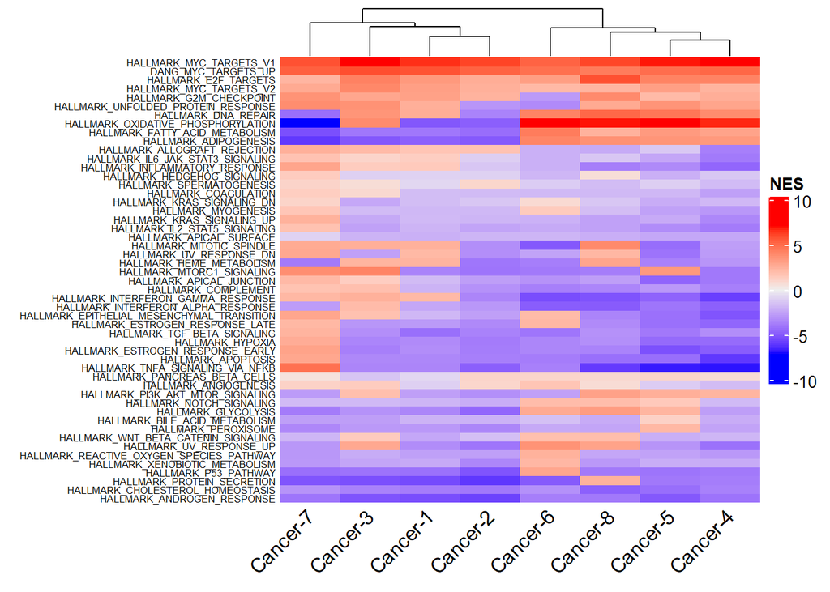

```r
library(tidyverse)
library(RColorBrewer)
library(ComplexHeatmap)
# make dataframe NES
fgsea_NES <- fgseaRes_Cancer1[, c("pathway", "NES")]
colnames(fgsea_NES)[2] <- "Cancer-1"
fgsea_NES$`Cancer-2` <- fgseaRes_Cancer2$NES
fgsea_NES$`Cancer-3` <- fgseaRes_Cancer3$NES
fgsea_NES$`Cancer-4` <- fgseaRes_Cancer4$NES
fgsea_NES$`Cancer-5` <- fgseaRes_Cancer5$NES
fgsea_NES$`Cancer-6` <- fgseaRes_Cancer6$NES
fgsea_NES$`Cancer-7` <- fgseaRes_Cancer7$NES
fgsea_NES$`Cancer-8` <- fgseaRes_Cancer8$NES

fgsea_NES <- column_to_rownames(fgsea_NES, var = "pathway")

fgsea_NES <- as.matrix(t(fgsea_NES))
colnames(fgsea_NES) <- colnames(fgsea_NES)
fgsea_NES <- t(fgsea_NES)

# heatmap of NES
Heatmap(fgsea_NES, column_dend_reorder = TRUE,
        show_row_dend = FALSE,
        row_names_side = "left",
        row_names_gp = gpar(fontsize = 6),
       column_names_rot = 45,
       heatmap_legend_param = list(
    title = "NES",
    legend_height = unit(4, "cm")
))
```

# Cancer vs Luminal: Differential expression analysis for ranked list and GSEA for Hallmark

Presto performs a fast Wilcoxon rank sum test and auROC analysis.

```r
cancer_genes <- wilcoxauc(X = seurat_epi, group_by = 'epithelial_groups', seurat_assay = 'SCT', assay = 'data', groups_use = c("Cancer", "Luminal"))
head(cancer_genes)
```

```
##      feature  group      avgExpr         logFC statistic       auc         pval
## 1 AL627309.1 Cancer 0.0001274168 -5.914961e-06 339366064 0.4999957 9.439569e-01
## 2 AL669831.5 Cancer 0.0423397277  4.277527e-04 339703942 0.5004935 6.349669e-01
## 3     FAM87B Cancer 0.0000000000  0.000000e+00 339368960 0.5000000 1.000000e+00
## 4  LINC00115 Cancer 0.0304009687  1.414663e-02 346155005 0.5099980 1.019802e-38
## 5     FAM41C Cancer 0.0029942939 -8.056602e-04 338974504 0.4994188 6.220626e-02
## 6 AL645608.1 Cancer 0.0009237715 -2.165080e-03 338308924 0.4984382 3.210612e-10
##           padj     pct_in   pct_out
## 1 1.000000e+00 0.01838235 0.0192357
## 2 8.907608e-01 5.94669118 5.8444473
## 3 1.000000e+00 0.00000000 0.0000000
## 4 6.724986e-38 4.30147059 2.3018723
## 5 1.170867e-01 0.43198529 0.5482175
## 6 1.031321e-09 0.13327206 0.4456271
```

```r
# saveRDS(cancer_genes, file = "cancer_genes.rds")

# we have all the genes for each cluster
dplyr::count(cancer_genes, group)
```

```
##     group     n
## 1  Cancer 22280
## 2 Luminal 22280
```

```r
# check of the gene-level statistic following wilcox rank sum test and auROC analysis
cancer_genes %>%
  dplyr::filter(group == "Cancer") %>%
  arrange(desc(logFC), desc(statistic)) %>%
  head(n = 10)
```

```
##    feature  group  avgExpr     logFC statistic       auc pval padj    pct_in
## 1    TRGC1 Cancer 1.527806 1.0275717 548716829 0.8084370    0    0  86.59926
## 2    TRPM4 Cancer 1.236042 0.8759079 556287017 0.8195903    0    0  84.11305
## 3     RPS2 Cancer 3.405119 0.8091720 574387469 0.8462581    0    0 100.00000
## 4   TMSB4X Cancer 2.082637 0.7715748 508514883 0.7492065    0    0  97.11857
## 5     AGR2 Cancer 1.235332 0.7549776 489127694 0.7206429    0    0  72.09099
## 6    RPL39 Cancer 2.829062 0.7397382 543759348 0.8011330    0    0  99.91728
## 7  SLC25A6 Cancer 1.729138 0.7086352 541696442 0.7980937    0    0  97.21507
## 8   PDLIM5 Cancer 1.456543 0.6523974 493998147 0.7278187    0    0  87.88603
## 9     RPS6 Cancer 3.480612 0.6267267 560088948 0.8251918    0    0 100.00000
## 10   RPS18 Cancer 3.787250 0.6247770 556486298 0.8198839    0    0 100.00000
##      pct_out
## 1   40.18979
## 2   38.11554
## 3   99.96153
## 4   90.40138
## 5   36.66966
## 6   99.57681
## 7   85.15966
## 8   70.24558
## 9  100.00000
## 10  99.99679
```

```r
cancer_genes %>%
  dplyr::filter(group == "Cancer") %>%
  arrange(desc(logFC), desc(statistic)) %>%
  tail(n = 10)
```

```
##       feature  group   avgExpr      logFC statistic        auc pval padj
## 22271     CD9 Cancer 1.4351963 -0.8783616 104644801 0.15417556    0    0
## 22272     B2M Cancer 2.3942886 -0.9044031 111232866 0.16388191    0    0
## 22273   TIMP1 Cancer 0.1677079 -0.9276384 125585240 0.18502759    0    0
## 22274   RDH11 Cancer 1.3410538 -0.9384773 139088835 0.20492274    0    0
## 22275   ADIRF Cancer 1.1041529 -1.1102285 141732606 0.20881787    0    0
## 22276   AZGP1 Cancer 1.4738175 -1.1415051  98622086 0.14530216    0    0
## 22277    MT2A Cancer 1.6129618 -1.1520367 162299687 0.23911982    0    0
## 22278    NEFH Cancer 0.1346575 -1.2275680 104655428 0.15419122    0    0
## 22279    ACPP Cancer 1.8671135 -1.9449103  64886352 0.09559854    0    0
## 22280    MSMB Cancer 2.0019760 -2.6672831  62000818 0.09134721    0    0
##         pct_in  pct_out
## 22271 92.48621 99.66017
## 22272 99.51746 99.99038
## 22273 18.13879 73.71441
## 22274 81.99449 98.74006
## 22275 66.94853 96.39972
## 22276 89.03952 99.66017
## 22277 85.39062 98.03796
## 22278 12.95496 76.49077
## 22279 84.34743 99.69223
## 22280 89.77941 99.69223
```

```r
# select only the feature and statistic columns for fgsea
cancer_genes<- cancer_genes %>%
  dplyr::filter(group == "Cancer") %>%
  arrange(desc(statistic)) %>%
  dplyr::select(feature, statistic)

ranks_cancer<- deframe(cancer_genes)
head(ranks_cancer)
```

```
##      RPS2      RPS6     RPS14     RPS18     TRPM4     TRGC1
## 574387469 560088948 558417802 556486298 556287017 548716829
```

```r
tail(ranks_cancer)
```

```
##       B2M      NEFH       CD9     AZGP1      ACPP      MSMB
## 111232866 104655428 104644801  98622086  64886352  62000818
```

```r
# perform analysis
fgseaRes_cancer <- fgsea(fgsea_sets, stats = ranks_cancer)
```

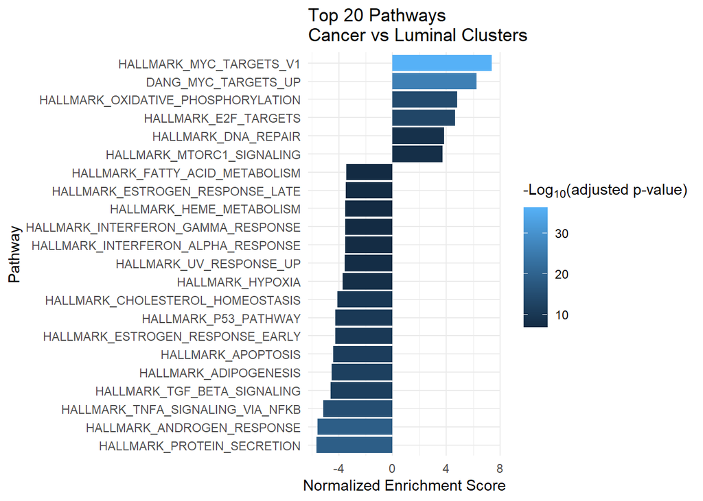

```r
# save results
# saveRDS(fgseaRes_cancer, file = "fgseaRes_cancer.rds")

# tidy the data
fgseaResTidy_cancer <- fgseaRes_cancer %>%
  as_tibble() %>%
  arrange(padj)

# add statistic
fgseaResTidy_cancer$statistic <- -log10(fgseaResTidy_cancer$padj)

# only plot the top 20 pathways for cancer
plot_CvsL <- ggplot(fgseaResTidy_cancer %>% filter(padj < 0.01, ) %>% top_n(20, -padj), aes(reorder(pathway, NES), NES)) +
  geom_col(aes(fill= statistic)) +
  coord_flip() +
  labs(x="Pathway", y="Normalized Enrichment Score",
       title="Top 20 Pathways \nCancer vs Luminal Clusters") +
  theme_minimal() + labs(fill = expression("-Log"[10]*"(adjusted p-value)"))
plot_CvsL
```

# Intermediate vs Luminal: Differential expression analysis for ranked list and GSEA for Hallmark

Presto performs a fast Wilcoxon rank sum test and auROC analysis.

```r
intermediate_genes <- wilcoxauc(X = seurat_epi, group_by = 'epithelial_groups', seurat_assay = 'SCT', assay = 'data', groups_use = c("Atrophic/Intermediate", "Luminal"))
head(intermediate_genes)
```

```
##      feature                 group     avgExpr         logFC statistic
## 1 AL627309.1 Atrophic/Intermediate 0.000000000 -0.0001333317 239336957
## 2 AL669831.5 Atrophic/Intermediate 0.018617505 -0.0232944697 231727767
## 3     FAM87B Atrophic/Intermediate 0.000000000  0.0000000000 239383004
## 4  LINC00115 Atrophic/Intermediate 0.017789367  0.0015350275 239877783
## 5     FAM41C Atrophic/Intermediate 0.004651388  0.0008514343 239677053
## 6 AL645608.1 Atrophic/Intermediate 0.001381190 -0.0017076619 238784198
##         auc         pval         padj    pct_in   pct_out
## 1 0.4999038 8.573204e-02 1.480935e-01 0.0000000 0.0192357
## 2 0.4840105 4.462682e-52 2.473347e-51 2.6516385 5.8444473
## 3 0.5000000 1.000000e+00 1.000000e+00 0.0000000 0.0000000
## 4 0.5010334 1.681624e-01 2.733989e-01 2.5083067 2.3018723
## 5 0.5006142 1.034201e-01 1.775192e-01 0.6710535 0.5482175
## 6 0.4987493 2.465908e-05 5.539546e-05 0.1954525 0.4456271
```

```r
# saveRDS(intermediate_genes, file = "intermediate_genes.rds")

# we have all the genes for each cluster
dplyr::count(intermediate_genes, group)
```

```
##                   group     n
## 1 Atrophic/Intermediate 22280
## 2               Luminal 22280
```

```r
# check of the gene-level statistic following wilcox rank sum test and auROC analysis
intermediate_genes %>%
  dplyr::filter(group == "Atrophic/Intermediate") %>%
  arrange(desc(logFC), desc(statistic)) %>%
  head(n = 10)
```

```
##    feature                 group   avgExpr     logFC statistic       auc pval
## 1    KRT19 Atrophic/Intermediate 1.9033074 1.4179904 388741294 0.8119651    0
## 2   S100A6 Atrophic/Intermediate 2.1300705 1.2968841 371721970 0.7764168    0
## 3    CXCL8 Atrophic/Intermediate 1.5386436 1.0333887 344531740 0.7196245    0
## 4     KRT7 Atrophic/Intermediate 1.0907811 0.9923475 364424587 0.7611747    0
## 5     MMP7 Atrophic/Intermediate 1.0790691 0.9839228 331132859 0.6916382    0
## 6      LTF Atrophic/Intermediate 1.1648734 0.9245510 295069274 0.6163121    0
## 7     LCN2 Atrophic/Intermediate 0.9484553 0.8648217 333498165 0.6965786    0
## 8    KRT17 Atrophic/Intermediate 1.1074322 0.8439782 338915126 0.7078930    0
## 9     CD74 Atrophic/Intermediate 1.0150436 0.8396990 343052749 0.7165353    0
## 10  TMSB4X Atrophic/Intermediate 2.1140181 0.8029557 359856800 0.7516340    0
##    padj   pct_in   pct_out
## 1     0 84.88501 46.188125
## 2     0 89.67359 62.298025
## 3     0 74.62375 40.850218
## 4     0 58.63574 11.060528
## 5     0 45.20164 10.425750
## 6     0 37.81354 18.947166
## 7     0 45.86618  9.544114
## 8     0 62.42752 29.786484
## 9     0 55.56714 19.508207
## 10    0 97.60245 90.401385
```

```r
intermediate_genes %>%
  dplyr::filter(group == "Atrophic/Intermediate") %>%
  arrange(desc(logFC), desc(statistic)) %>%
  tail(n = 10)
```

```
##       feature                 group   avgExpr     logFC statistic        auc
## 22271   DHRS7 Atrophic/Intermediate 0.6349594 -1.032719  65876341 0.13759611
## 22272     DBI Atrophic/Intermediate 0.9238651 -1.086381  68570093 0.14322256
## 22273    NEFH Atrophic/Intermediate 0.2241406 -1.138085  85388059 0.17835030
## 22274    KLK4 Atrophic/Intermediate 0.6642972 -1.160680  65763979 0.13736142
## 22275     NPY Atrophic/Intermediate 0.5120232 -1.295650 102260660 0.21359215
## 22276   RDH11 Atrophic/Intermediate 0.8011950 -1.478336  41555307 0.08679669
## 22277    KLK2 Atrophic/Intermediate 1.5147264 -1.854672  42776732 0.08934789
## 22278    KLK3 Atrophic/Intermediate 2.1978099 -2.346195  33772799 0.07054135
## 22279    ACPP Atrophic/Intermediate 1.3449138 -2.467110  23398132 0.04887175
## 22280    MSMB Atrophic/Intermediate 2.1891495 -2.480110  57931866 0.12100246
##       pval padj   pct_in  pct_out
## 22271    0    0 61.60662 95.75212
## 22272    0    0 76.86494 97.87766
## 22273    0    0 22.35976 76.49077
## 22274    0    0 57.93211 95.91883
## 22275    0    0 46.55026 79.62619
## 22276    0    0 65.42446 98.74006
## 22277    0    0 81.79034 99.95832
## 22278    0    0 90.99616 99.99679
## 22279    0    0 75.82904 99.69223
## 22280    0    0 91.16555 99.69223
```

```r
# select only the feature and statistic columns for fgsea
intermediate_genes<- intermediate_genes %>%
  dplyr::filter(group == "Atrophic/Intermediate") %>%
  arrange(desc(statistic)) %>%
  dplyr::select(feature, statistic)

ranks_intermediate<- deframe(intermediate_genes)
head(ranks_intermediate)
```

```
##     KRT19    S100A6      EIF1      KRT7    TMSB4X   S100A11
## 388741294 371721970 365009359 364424587 359856800 350985786
```

```r
tail(ranks_intermediate)
```

```
##     KLK4     MSMB     KLK2    RDH11     KLK3     ACPP
## 65763979 57931866 42776732 41555307 33772799 23398132
```

```r
# perform analysis
fgseaRes_intermediate <- fgsea(fgsea_sets, stats = ranks_intermediate)
```

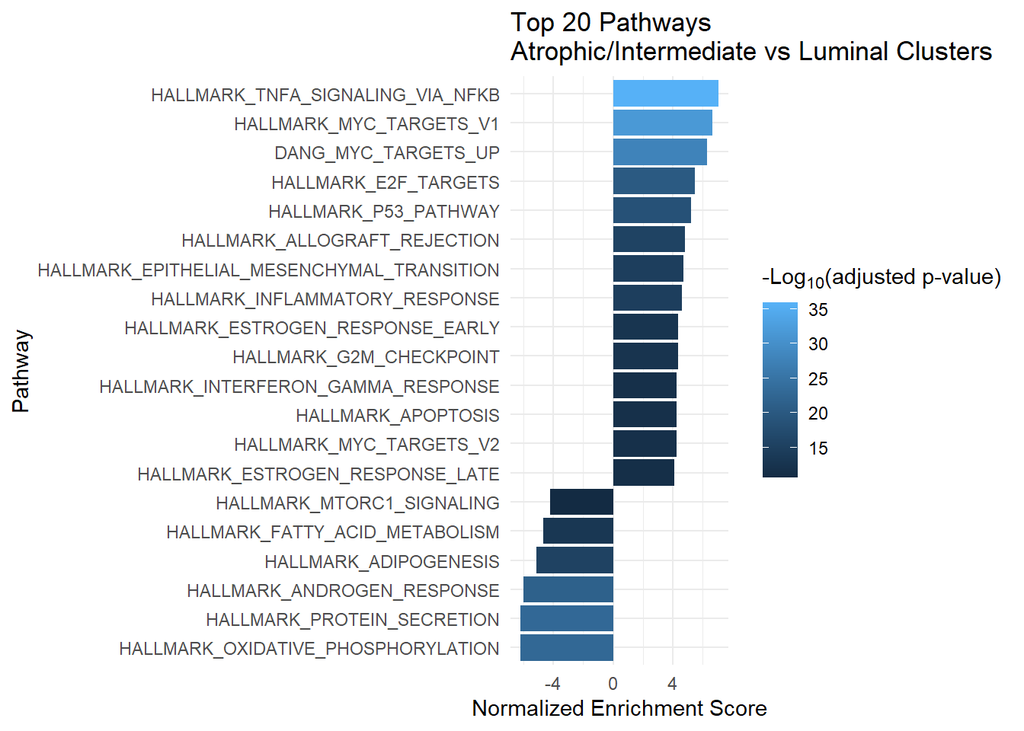

```r
# save results
# saveRDS(fgseaRes_intermediate, file = "fgseaRes_intermediate.rds")

# tidy the data
fgseaResTidy_intermediate <- fgseaRes_intermediate %>%
  as_tibble() %>%
  arrange(padj)

# add statistic
fgseaResTidy_intermediate$statistic <- -log10(fgseaResTidy_intermediate$padj)

## only plot the top 20 pathways for intermediate
plot_inter <- ggplot(fgseaResTidy_intermediate %>% filter(padj < 0.01, ) %>% top_n(20, -padj), aes(reorder(pathway, NES), NES)) +
  geom_col(aes(fill= statistic)) +
  coord_flip() +
  labs(x="Pathway", y="Normalized Enrichment Score",
       title="Top 20 Pathways \nAtrophic/Intermediate vs Luminal Clusters") +
  theme_minimal() + labs(fill =  expression("-Log"[10]*"(adjusted p-value)"))
plot_inter
```

# Intermediate vs cancer: Differential expression analysis for ranked list and GSEA for Hallmark

Presto performs a fast Wilcoxon rank sum test and auROC analysis.

```r
Int_cancer_genes <- wilcoxauc(X = seurat_epi, group_by = 'epithelial_groups', seurat_assay = 'SCT', assay = 'data', groups_use = c("Atrophic/Intermediate", "Cancer"))
head(Int_cancer_genes)
```

```
##      feature                 group     avgExpr         logFC statistic
## 1 AL627309.1 Atrophic/Intermediate 0.000000000 -0.0001274168 166966422
## 2 AL669831.5 Atrophic/Intermediate 0.018617505 -0.0237222224 161488484
## 3     FAM87B Atrophic/Intermediate 0.000000000  0.0000000000 166997120
## 4  LINC00115 Atrophic/Intermediate 0.017789367 -0.0126116012 164003367
## 5     FAM41C Atrophic/Intermediate 0.004651388  0.0016570945 167396357
## 6 AL645608.1 Atrophic/Intermediate 0.001381190  0.0004574182 167100974
##         auc         pval         padj    pct_in    pct_out
## 1 0.4999081 9.300113e-02 1.606377e-01 0.0000000 0.01838235
## 2 0.4835068 1.282020e-50 8.756407e-50 2.6516385 5.94669118
## 3 0.5000000 1.000000e+00 1.000000e+00 0.0000000 0.00000000
## 4 0.4910365 4.363536e-20 1.713120e-19 2.5083067 4.30147059
## 5 0.5011953 1.801861e-03 3.801295e-03 0.6710535 0.43198529
## 6 0.5003109 1.386609e-01 2.343979e-01 0.1954525 0.13327206
```

```r
# saveRDS(Int_cancer_genes, file = "Int_cancer_genes.rds")

# we have all the genes for each cluster
dplyr::count(Int_cancer_genes, group)
```

```
##                   group     n
## 1 Atrophic/Intermediate 22280
## 2                Cancer 22280
```

```r
# check of the gene-level statistic following wilcox rank sum test and auROC analysis
Int_cancer_genes %>%
  dplyr::filter(group == "Cancer") %>%
  arrange(desc(logFC), desc(statistic)) %>%
  head(n = 10)
```

```
##    feature  group  avgExpr     logFC statistic       auc pval padj   pct_in
## 1     KLK3 Cancer 3.762548 1.5647381 272118705 0.8147407    0    0 99.68750
## 2     KLK2 Cancer 2.821113 1.3063861 274520580 0.8219321    0    0 99.63235
## 3    TRGC1 Cancer 1.527806 1.2474718 290522855 0.8698439    0    0 86.59926
## 4      NPY Cancer 1.572825 1.0608016 211728076 0.6339273    0    0 57.28860
## 5     TFF3 Cancer 1.589552 1.0272016 232761753 0.6969035    0    0 68.81434
## 6    TRPM4 Cancer 1.236042 0.9207676 276937137 0.8291674    0    0 84.11305
## 7    SPON2 Cancer 1.076335 0.8632568 236206839 0.7072183    0    0 55.51930
## 8    GOLM1 Cancer 1.171318 0.7472792 263164328 0.7879307    0    0 83.54320
## 9   PDLIM5 Cancer 1.456543 0.7136586 250096165 0.7488038    0    0 87.88603
## 10    KLK4 Cancer 1.345572 0.6812753 245663671 0.7355327    0    0 86.66360
##     pct_out
## 1  90.99616
## 2  81.79034
## 3  27.98228
## 4  46.55026
## 5  48.62206
## 6  31.77406
## 7  22.27507
## 8  44.72604
## 9  69.20972
## 10 57.93211
```

```r
Int_cancer_genes %>%
  dplyr::filter(group == "Cancer") %>%
  arrange(desc(logFC), desc(statistic)) %>%
  tail(n = 10)
```

```
##       feature  group    avgExpr      logFC statistic       auc pval padj
## 22271   HLA-A Cancer 0.52793520 -0.9145771  61161023 0.1831200    0    0
## 22272   KRT17 Cancer 0.18569377 -0.9217384  87084684 0.2607371    0    0
## 22273   WFDC2 Cancer 0.03912264 -0.9753867  79402619 0.2377365    0    0
## 22274    IER3 Cancer 0.19022585 -1.0134038  61621944 0.1845000    0    0
## 22275    KRT7 Cancer 0.07027708 -1.0205041  76705729 0.2296618    0    0
## 22276    MMP7 Cancer 0.05095038 -1.0281187  97640116 0.2923407    0    0
## 22277   ANXA2 Cancer 0.97076752 -1.0285133  64237811 0.1923321    0    0
## 22278     LTF Cancer 0.04790180 -1.1169716 110045611 0.3294836    0    0
## 22279   KRT19 Cancer 0.52886164 -1.3744457  65848213 0.1971537    0    0
## 22280  S100A6 Cancer 0.31142541 -1.8186451  38007223 0.1137960    0    0
##          pct_in  pct_out
## 22271 50.036765 91.97342
## 22272 20.588235 62.42752
## 22273  4.664522 55.25441
## 22274 20.882353 75.70526
## 22275  7.895221 58.63574
## 22276  5.560662 45.20164
## 22277 72.113971 97.17245
## 22278  5.261949 37.81354
## 22279 46.852022 84.88501
## 22280 32.284007 89.67359
```

```r
# select only the feature and statistic columns for fgsea
Int_cancer_genes<- Int_cancer_genes %>%
  dplyr::filter(group == "Cancer") %>%
  arrange(desc(statistic)) %>%
  dplyr::select(feature, statistic)

ranks_Int_cancer<- deframe(Int_cancer_genes)
head(ranks_Int_cancer)
```

```
##     TRGC1     TRPM4      KLK2      KLK3     GOLM1    RPL37A
## 290522855 276937137 274520580 272118705 263164328 262052225
```

```r
tail(ranks_Int_cancer)
```

```
##    KRT19    GSTP1    ANXA2     IER3    HLA-A   S100A6
## 65848213 64449922 64237811 61621944 61161023 38007223
```

```r
# perform analysis
fgseaRes_Int_cancer <- fgsea(fgsea_sets, stats = ranks_Int_cancer)
```

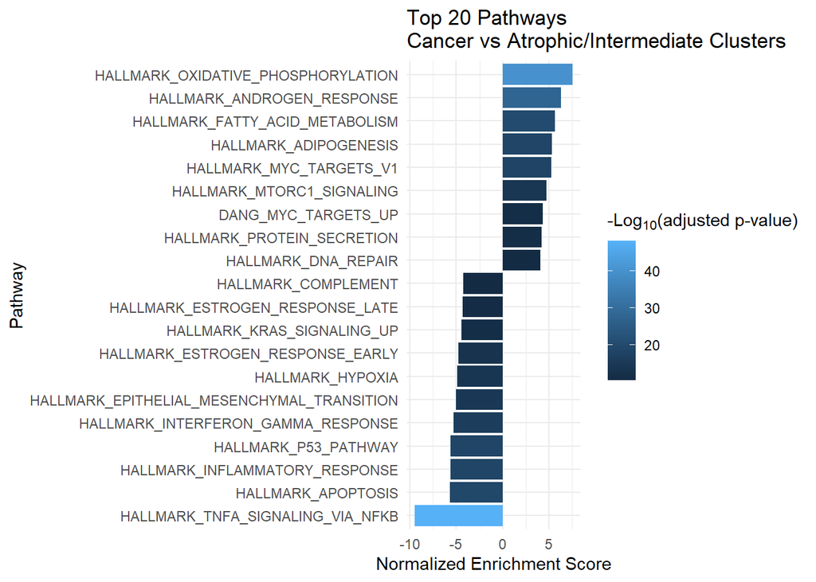

```r
# save results
# saveRDS(fgseaRes_Int_cancer, file = "fgseaRes_Int_cancer.rds")

# tidy the data
fgseaResTidy_Int_cancer <- fgseaRes_Int_cancer %>%
  as_tibble() %>%
  arrange(padj)

# add statistic
fgseaResTidy_Int_cancer$statistic <- -log10(fgseaResTidy_Int_cancer$padj)

## only plot the top 20 pathways for Int_cancer
plot_interCan <- ggplot(fgseaResTidy_Int_cancer %>% filter(padj < 0.01, ) %>% top_n(20, -padj), aes(reorder(pathway, NES), NES)) +
  geom_col(aes(fill= statistic)) +
  coord_flip() +
  labs(x="Pathway", y="Normalized Enrichment Score",
       title="Top 20 Pathways \nCancer vs Atrophic/Intermediate Clusters") +
  theme_minimal() + labs(fill =  expression("-Log"[10]*"(adjusted p-value)"))
plot_interCan
```

# Basal vs Luminal: Differential expression analysis for ranked list and GSEA for Hallmark Presto performs a fast Wilcoxon rank sum test and auROC analysis.

```r
Basal_genes <- wilcoxauc(X = seurat_epi, group_by = 'epithelial_groups', seurat_assay = 'SCT', assay = 'data', groups_use = c("Basal", "Luminal"))
head(Basal_genes)
```

```
##      feature group      avgExpr         logFC statistic       auc         pval
## 1 AL627309.1 Basal 0.0000000000 -0.0001333317 160919760 0.4999038 1.588332e-01
## 2 AL669831.5 Basal 0.0087543314 -0.0331576436 153537552 0.4769707 7.522215e-82
## 3     FAM87B Basal 0.0000000000  0.0000000000 160950720 0.5000000 1.000000e+00
## 4  LINC00115 Basal 0.0053453578 -0.0109089822 158477375 0.4923165 6.136350e-23
## 5     FAM41C Basal 0.0047687451  0.0009687911 161175676 0.5006988 1.059512e-01
## 6 AL645608.1 Basal 0.0003358271 -0.0027530244 160311460 0.4980141 2.704869e-09
##           padj     pct_in   pct_out
## 1 2.571806e-01 0.00000000 0.0192357
## 2 3.596458e-81 1.24031008 5.8444473
## 3 1.000000e+00 0.00000000 0.0000000
## 4 1.665463e-22 0.76550388 2.3018723
## 5 1.755870e-01 0.68798450 0.5482175
## 6 5.835059e-09 0.04844961 0.4456271
```

```r
# saveRDS(Basal_genes, file = "Basal_genes.rds")

# we have all the genes for each cluster
dplyr::count(Basal_genes, group)
```

```
##     group     n
## 1   Basal 22280
## 2 Luminal 22280
```

```r
# check of the gene-level statistic following wilcox rank sum test and auROC analysis
Basal_genes %>%
  dplyr::filter(group == "Basal") %>%
  arrange(desc(logFC), desc(statistic)) %>%
  head(n = 10)
```

```
##    feature group  avgExpr    logFC statistic       auc pval padj   pct_in
## 1    KRT17 Basal 3.553984 3.290530 317155146 0.9852554    0    0 98.40116
## 2   S100A2 Basal 2.601533 2.435819 288744746 0.8969974    0    0 84.17636
## 3   S100A6 Basal 2.999361 2.166174 302691232 0.9403227    0    0 99.59302
## 4  GADD45A Basal 2.125559 1.862670 308230693 0.9575313    0    0 95.64922
## 5    KRT19 Basal 2.250765 1.765448 285281357 0.8862382    0    0 90.77519
## 6    CXCL8 Basal 2.121914 1.616659 260727691 0.8099612    0    0 82.64535
## 7     KRT5 Basal 1.390523 1.365059 287940508 0.8944990    0    0 80.03876
## 8    KRT14 Basal 1.403813 1.346976 247513679 0.7689114    0    0 57.47093
## 9      SFN Basal 2.736509 1.330501 273702160 0.8502670    0    0 99.14729
## 10 TACSTD2 Basal 3.112598 1.329151 283524630 0.8807809    0    0 99.74806
##      pct_out
## 1  29.786484
## 2  19.415235
## 3  62.298025
## 4  28.494486
## 5  46.188125
## 6  40.850218
## 7   2.984740
## 8   7.043473
## 9  86.650423
## 10 96.858169
```

```r
Basal_genes %>%
  dplyr::filter(group == "Basal") %>%
  arrange(desc(logFC), desc(statistic)) %>%
  tail(n = 10)
```

```
##       feature group   avgExpr     logFC statistic         auc pval padj
## 22271     CPE Basal 0.3348751 -1.351813  20964360 0.065126644    0    0
## 22272   ADIRF Basal 0.7745964 -1.439785  33321732 0.103515326    0    0
## 22273     DBI Basal 0.5624758 -1.447771  19995684 0.062117411    0    0
## 22274    KLK4 Basal 0.2923763 -1.532601  16033743 0.049809480    0    0
## 22275   RDH11 Basal 0.4076596 -1.871872   8473146 0.026322173    0    0
## 22276   AZGP1 Basal 0.6941205 -1.921202   8623382 0.026788889    0    0
## 22277    KLK2 Basal 0.8230690 -2.546329   2726484 0.008469936    0    0
## 22278    ACPP Basal 0.7296422 -3.082382   3368238 0.010463569    0    0
## 22279    KLK3 Basal 1.3509922 -3.193012   1637935 0.005088311    0    0
## 22280    MSMB Basal 1.4392956 -3.229964  10827971 0.033637535    0    0
##         pct_in  pct_out
## 22271 39.56395 95.89638
## 22272 69.52519 96.39972
## 22273 61.31783 97.87766
## 22274 37.20930 95.91883
## 22275 48.03295 98.74006
## 22276 67.50000 99.66017
## 22277 72.03488 99.95832
## 22278 66.98643 99.69223
## 22279 88.45930 99.99679
## 22280 91.14341 99.69223
```

```r
# select only the feature and statistic columns for fgsea
Basal_genes<- Basal_genes %>%
  dplyr::filter(group == "Basal") %>%
  arrange(desc(statistic)) %>%
  dplyr::select(feature, statistic)

ranks_Basal<- deframe(Basal_genes)
head(ranks_Basal)
```

```
##     KRT17   GADD45A    S100A6   S100A11      EIF1     GSTP1
## 317155146 308230693 302691232 297984440 295113313 289318731
```

```r
tail(ranks_Basal)
```

```
##     MSMB    AZGP1    RDH11     ACPP     KLK2     KLK3
## 10827971  8623382  8473146  3368238  2726484  1637935
```

```r
# perform analysis
fgseaRes_Basal <- fgsea(fgsea_sets, stats = ranks_Basal)
```

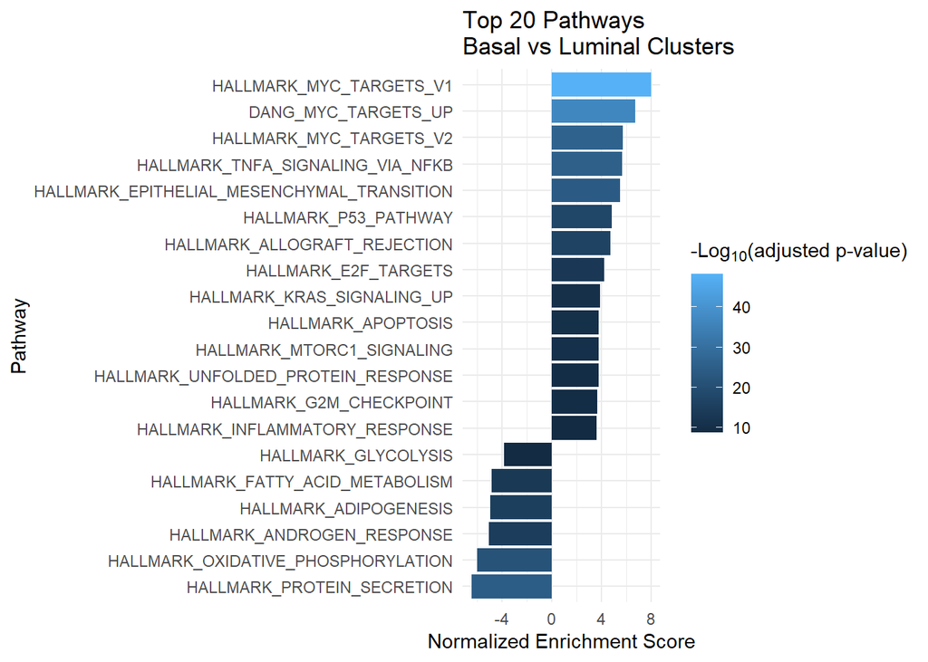

```r
# save results
# saveRDS(fgseaRes_Basal, file = "fgseaRes_Basal.rds")

# tidy the data
fgseaResTidy_Basal <- fgseaRes_Basal %>%
  as_tibble() %>%
  arrange(padj)

# add statistic
fgseaResTidy_Basal$statistic <- -log10(fgseaResTidy_Basal$padj)

# only plot the top 20 pathways for Basal
plot_Basal <- ggplot(fgseaResTidy_Basal %>% filter(padj < 0.01, ) %>% top_n(20, -padj), aes(reorder(pathway, NES), NES)) +
  geom_col(aes(fill= statistic)) +
  coord_flip() +
  labs(x="Pathway", y="Normalized Enrichment Score",
       title="Top 20 Pathways \nBasal vs Luminal Clusters") +
  theme_minimal() + labs(fill = expression("-Log"[10]*"(adjusted p-value)"))
plot_Basal
```

# MYC gene signature

Identify genes that were upregulated in cancer

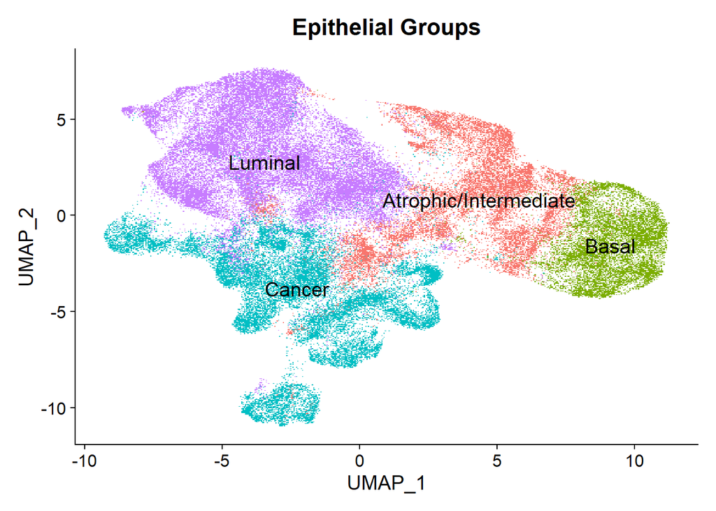

```r
library(UCell)
library(stringr)
library(patchwork)

DimPlot(seurat_epi, group.by = "epithelial_groups", label = TRUE, raster = TRUE, label.size = 5) + NoLegend() + ggtitle("Epithelial Groups")
```

```r
# MYC cancer leading edge
leadingEdge_MYC <- fgseaRes_cancer %>% filter(pathway == "HALLMARK_MYC_TARGETS_V1") %>% select(leadingEdge) %>% unlist() %>% as.data.frame()

#as.character(fgseaRes_cancer$leadingEdge)

# saveRDS(leadingEdge_MYC, file = "leadingEdgeMYCV1.rds")

GeneSig <- list()
GeneSig$MYC_GeneSig <- leadingEdge_MYC$.
GeneSig
```

```
## $MYC_GeneSig
##   [1] "RPS2"     "RPS6"     "RPS3"     "RACK1"    "RPL6"     "RPL34"
##   [7] "RPL14"    "RPLP0"    "EEF1B2"   "RPS5"     "HNRNPA1"  "NPM1"
##  [13] "HSPD1"    "NAP1L1"   "RPL18"    "IMPDH2"   "PABPC1"   "RPL22"
##  [19] "RSL1D1"   "RPS10"    "EIF3D"    "SRM"      "TCP1"     "RANBP1"
##  [25] "HSPE1"    "APEX1"    "PPIA"     "CNBP"     "NHP2"     "CBX3"
##  [31] "FBL"      "POLD2"    "CCT3"     "NME1"     "CCT4"     "LSM7"
##  [37] "IFRD1"    "GNL3"     "PABPC4"   "SSBP1"    "DUT"      "SERBP1"
##  [43] "PPM1G"    "SLC25A3"  "COX5A"    "SNRPD2"   "PA2G4"    "SNRPD1"
##  [49] "CLNS1A"   "SRPK1"    "AP3S1"    "GLO1"     "CCT2"     "HSP90AB1"
##  [55] "C1QBP"    "BUB3"     "CYC1"     "CDK4"     "SET"      "PHB2"
##  [61] "NDUFAB1"  "EIF2S2"   "TUFM"     "EIF3J"    "DDX21"    "MRPL23"
##  [67] "NCBP2"    "UBE2E1"   "SNRPA1"   "PTGES3"   "SRSF7"    "RNPS1"
##  [73] "HNRNPC"   "LSM2"     "LDHA"     "SNRPB2"   "PRDX4"    "VDAC3"
##  [79] "POLE3"    "ABCE1"    "MRPL9"    "RAN"      "NOP16"    "AIMP2"
##  [85] "PSMA1"    "ILF2"     "RAD23B"   "PSMA4"    "KPNA2"    "ERH"
##  [91] "SNRPA"    "TXNL4A"   "SRSF1"    "SRSF3"    "GSPT1"    "SMARCC1"
##  [97] "SRSF2"    "CCT5"     "USP1"     "PSMA6"    "VBP1"     "TFDP1"
## [103] "CCT7"     "PRPF31"   "MCM7"     "CTPS1"    "RUVBL2"   "XRCC6"
## [109] "PWP1"     "DDX18"    "YWHAQ"    "HNRNPU"   "RRP9"     "ACP1"
## [115] "EXOSC7"
```

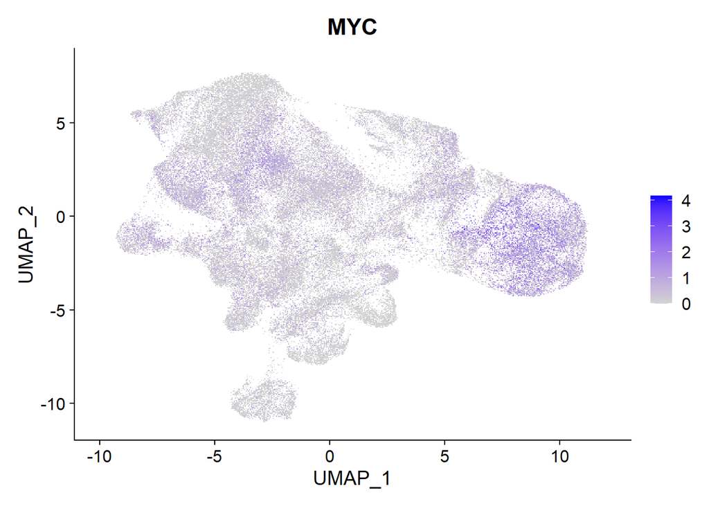

```r
# perform gene signature analysis using leading edge genes from MYC V1 pathway analysis
seurat_epi <- AddModuleScore_UCell(seurat_epi, features = GeneSig)

# UMAP of MYC expression
FeaturePlot(seurat_epi, reduction = "umap", features = "MYC", order = TRUE, raster = TRUE)
```

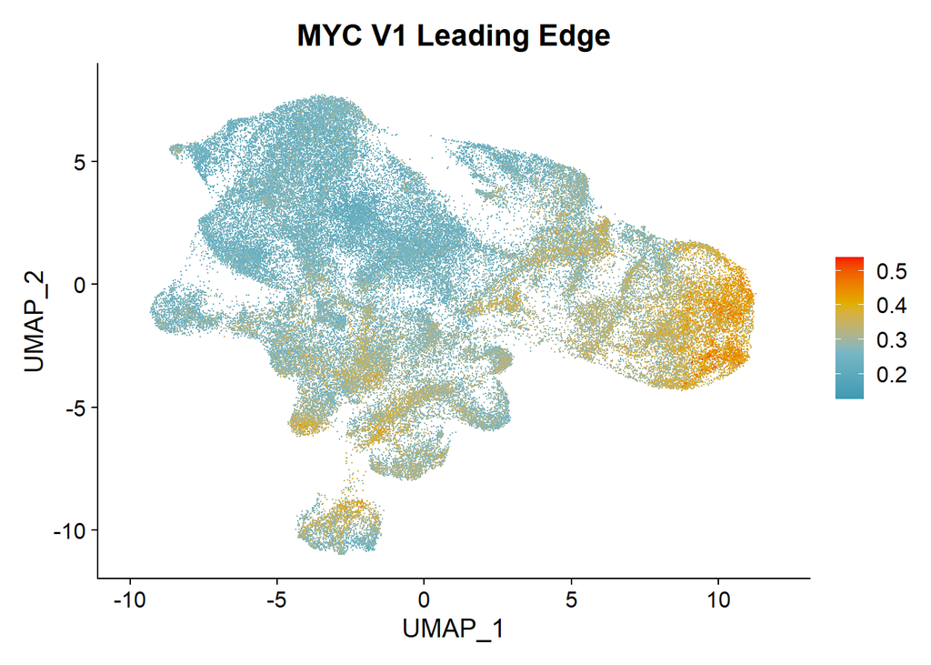

```r
# UMAP of MYC target genes
pal1 <- c("#3B9AB2", "#78B7C5", "#E1AF00", "#F21A00")
FeaturePlot(seurat_epi, reduction = "umap", features = "MYC_GeneSig_UCell", order = TRUE, raster = FALSE) +
  scale_color_gradientn(colours = pal1) + ggtitle("MYC V1 Leading Edge")
```